# ARIMA Model Analysis of Monthly Revenue

Md. Ariful Islam

2025-05-24

# Introduction

This report presents a time series analysis of monthly revenue data using the ARIMA model. The analysis includes data preparation, exploratory visualization, stationarity checks, model identification using ACF and PACF, model fitting, and forecasting future revenue trends.

# Data Preparation

```r
df <- read_csv("sales_data.csv")
df$Date <- ymd(df$Date)

monthly_revenue <- df %>%
  group_by(Date = floor_date(Date, "month")) %>%
  summarise(Revenue = sum(Revenue, na.rm = TRUE))

head(monthly_revenue)
```

```
## # A tibble: 6 × 2
##   Date       Revenue
##   <date>       <dbl>
## 1 2011-01-01  675193
## 2 2011-02-01  637598
## 3 2011-03-01  708517
## 4 2011-04-01  698782
## 5 2011-05-01  734537
## 6 2011-06-01  658138
```

# Exploratory Data Analysis

We start by visualizing the monthly revenue to detect any visible trend or seasonality.

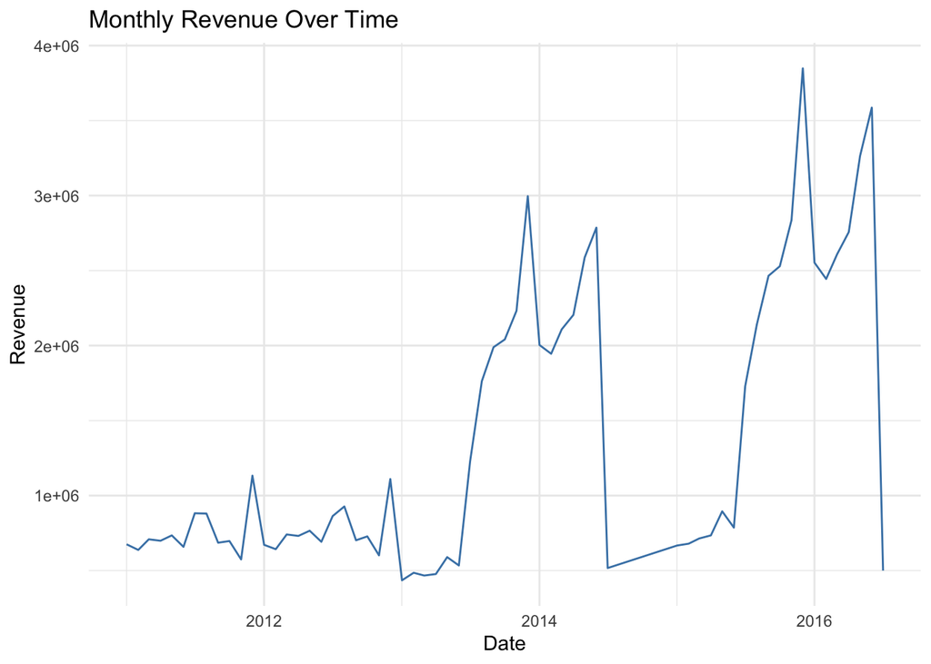

```r
ggplot(monthly_revenue, aes(x = Date, y = Revenue)) +
  geom_line(color = "steelblue") +
  labs(title = "Monthly Revenue Over Time", x = "Date", y = "Revenue") +
  theme_minimal()
```

# Stationarity Test

We apply the Augmented Dickey-Fuller (ADF) test to check whether the revenue time series is stationary.

```r
adf_test <- adf.test(monthly_revenue$Revenue, alternative = "stationary")
adf_test
```

```
##
##  Augmented Dickey-Fuller Test
##
## data:  monthly_revenue$Revenue
## Dickey-Fuller = -2.6564, Lag order = 3, p-value = 0.3092
## alternative hypothesis: stationary
```

# Autocorrelation and Partial Autocorrelation Plots

These plots help determine the AR and MA terms of the ARIMA model.

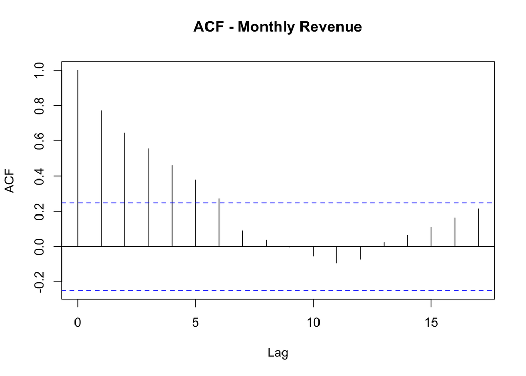

```r
acf(monthly_revenue$Revenue, main = "ACF - Monthly Revenue")
```

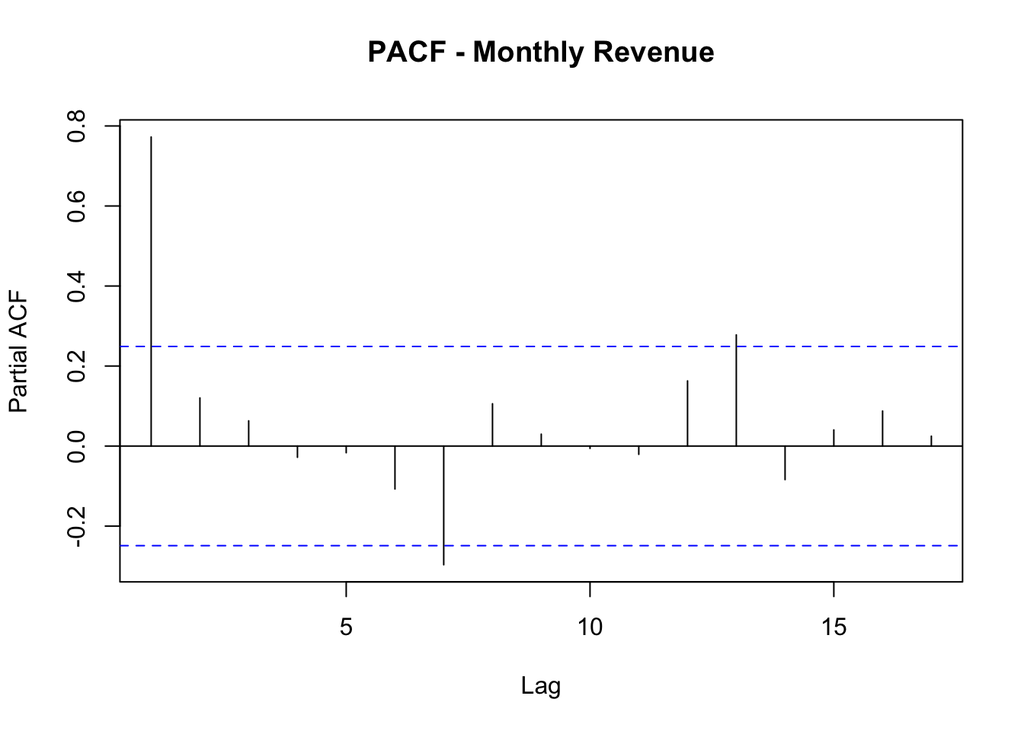

```r
pacf(monthly_revenue$Revenue, main = "PACF - Monthly Revenue")
```